# R Code Full Analysis Picture Naming Reaction Times

Elise Oosterhuis

Last compiled on 21/12/21

# Analysis Picture Naming Reaction Times GBG online study

## Descriptives

*Mean and standard deviations picture naming tasks*

```r
options(dplyr.summarise.inform = FALSE) #Suppress summarise message (`summarise()` has grouped output by 'Task.Name', 'Age.Category'. You can override using the `.groups` argument.) in output

# Combine both picture-naming datasets
PN_all <- rbind(PNobjects, PNactions) %>%
  convert(chr(type)) %>%
  dplyr::mutate(Task.Name=dplyr::recode(Task.Name, 'Picture Naming Task - Actions' #Change task names
                                = "Actions", 'Picture Naming Task - Objects'
                                = "Objects")) %>%
  dplyr::mutate(Age.Category=as.factor(dplyr::recode(Age.Category, '18 to 30 years old'=1, #Recode age groups as numeric values
                                    '40 to 55 years old'=2,
                                    '65 to 80 years old'=3)))

#Filter out outliers for Reaction Time for the combined dataset
PN_RT <- PN_all %>%
  dplyr::filter(Acc==1) %>% #Acc==1 means only correctly answered trials will be included, i.e., removing all incorrect trials
#Create z scores for reaction time per age group (younger, middle-aged, and older adults) and per type (Actions and Objects separately)
  group_by(Age.Category, type) %>%
  mutate(zRT = scale(RT)) %>%
#Use the z scores to filter out outliers (i.e., exclude values +/-2.5 SD per trial )
  filter(between(zRT, -2.5, +2.5)) %>%
  ungroup()

# Mean and SD for picture naming
## Reaction Time (only correct trials; outliers excluded)
(PNrt_sum <- PN_RT %>%
    group_by(Task.Name, Age.Category) %>%
#Obtain mean and standard deviation for reaction time per task (actions and objects separately) and Age Group
    dplyr::summarise(mean_RT = round(mean(RT, na.rm=T),2),
            sd_RT = round(sd(RT,na.rm=T),2)))
```

```
## # A tibble: 6 x 4
## # Groups:   Task.Name [2]
##   Task.Name Age.Category mean_RT sd_RT
##   <chr>     <fct>          <dbl> <dbl>
## 1 Actions   1              1064.  348.
## 2 Actions   2              1007.  312.
## 3 Actions   3              1071.  327.
## 4 Objects   1               764.  183.
## 5 Objects   2               793.  222.
## 6 Objects   3               881.  247.
```

```r
## Save output table as .csv fil
# write.csv(PNrt_sum, file = "./Figures and Tables/Descriptives_PNrt.csv", row.names = F)e
```

### Plots for Reaction Time

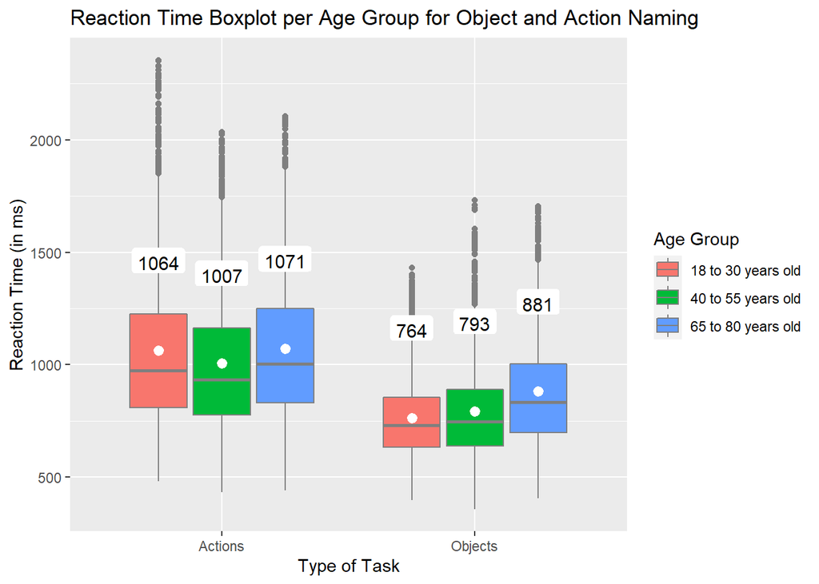

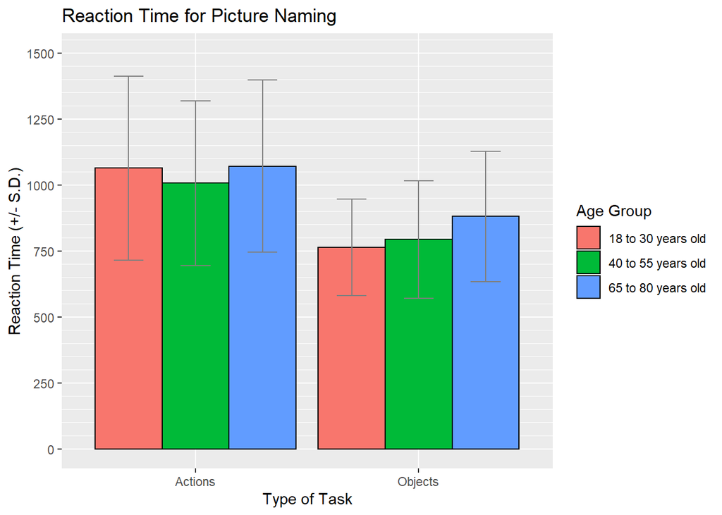

#### Missing data CR composite variable

The missing data for the CR composite variable posed a problem in that it removed all data of participants with missing data in the LMEs. To solve this problem, we agreed on replacing values with the means per age category per CR subscale. As some participants were extreme outliers, we decided to winsorize at -2.5 and 2.5 SD. In this way, extreme values were still extreme values but wouldn’t be excluded and, hence, result in missing values. This procedure led to no missing values and no excluded participants in our statistical models.

## Statistical Analysis

### Linear Mixed Models - Action naming

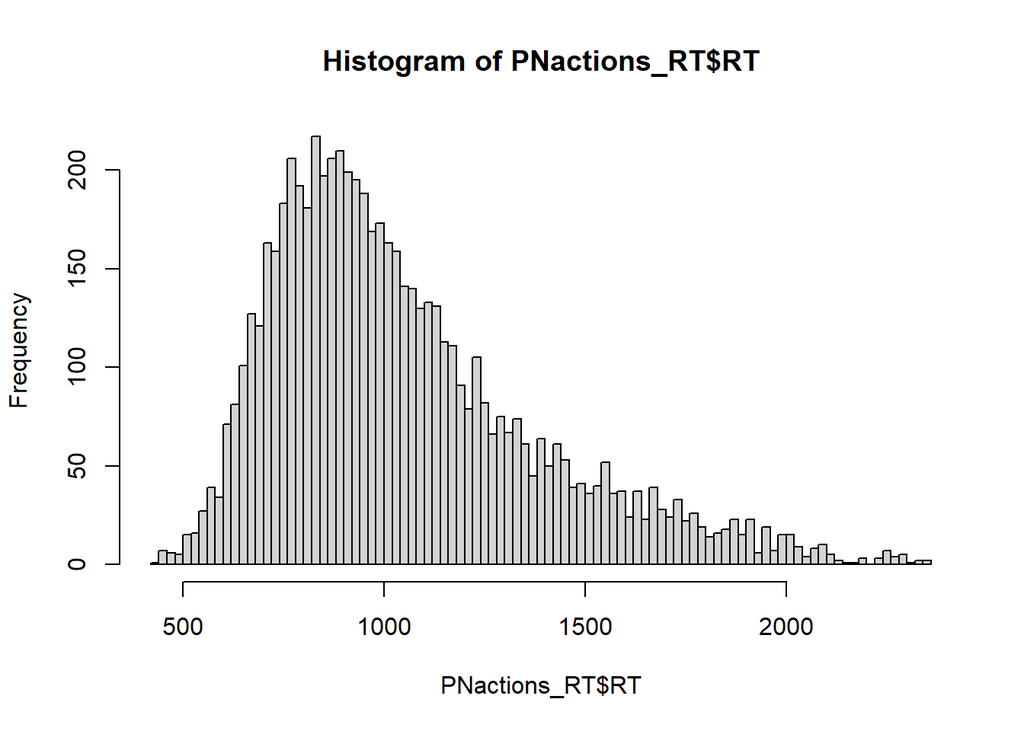

```r
# Only include trials for action naming (i.e., type==1)
PNactions_RT <- PN_RT %>%
  dplyr::filter(type==1)
  # Check
    # unique(PNactions_RT$Task.Name) #actions

## Create histogram for distribution
hist(PNactions_RT$RT, breaks = 100)
```

#### Check for Skewness seen the histograms

```r
skewness(log(PNactions_RT$RT))
```

```
## [1] 0.3443259
```

*Should we include random effects for ID and Trial.Number?*

```r
#Base model with log-transformed reaction time
Mbase_act <- lm(log(RT) ~ 1, data=PNactions_RT)

#Base model with only ID/individual variability as random effect
Mrandom.ID_act <- lmer(log(RT) ~ 1 +(1|ID), data=PNactions_RT)
#Base model with only Trial.Number/trial variability as random effect
Mrandom.Trial_act <- lmer(log(RT) ~ 1 +(1|Trial.Number), data=PNactions_RT)
#Base model with both random effects
Mrandom.All_act <- lmer(log(RT) ~ 1 +(1|ID) + (1|Trial.Number), data=PNactions_RT)
```

AIC base model

```r
#Obtain AIC values for each model
(AIC.base_act <- AIC(logLik(Mbase_act)))
```

```
## [1] 2660.319
```

AIC - only ID as random effect

```r
(AIC.reID_act <- AIC(logLik(Mrandom.ID_act)))
```

```
## [1] 1773.477
```

AIC - only trial as random effect

```r
(AIC.reTrial_act <- AIC(logLik(Mrandom.Trial_act)))
```

```
## [1] 1793.343
```

AIC - both ID and trial as random effect

```r
(AIC.reBoth_act <- AIC(logLik(Mrandom.All_act)))
```

```
## [1] 603.5965
```

The AIC for the model including both random effects is lowest –> we justified inclusion of both Trial and Subject as random effects.

*Null model of reaction times for action naming with random effects included*

```r
M0_PNactRT <- lmer(RT ~ 1 +(1|ID) + (1|Trial.Number), data=PNactions_RT, REML=FALSE)
summary(M0_PNactRT)
```

```
## Linear mixed model fit by maximum likelihood . t-tests use Satterthwaite's
##   method [lmerModLmerTest]
## Formula: RT ~ 1 + (1 | ID) + (1 | Trial.Number)
##    Data: PNactions_RT
##
##      AIC      BIC   logLik deviance df.resid
##  91855.2  91882.3 -45923.6  91847.2     6473
##
## Scaled residuals:
##     Min      1Q  Median      3Q     Max
## -2.4808 -0.6632 -0.1852  0.4395  5.0949
##
## Random effects:
##  Groups       Name        Variance Std.Dev.
##  ID           (Intercept) 15602    124.9
##  Trial.Number (Intercept) 16850    129.8
##  Residual                 78421    280.0
## Number of obs: 6477, groups:  ID, 90; Trial.Number, 79
##
## Fixed effects:
##             Estimate Std. Error      df t value Pr(>|t|)
## (Intercept)  1053.35      19.99  153.51   52.69   <2e-16 ***
## ---
## Signif. codes:  0 '***' 0.001 '**' 0.01 '*' 0.05 '.' 0.1 ' ' 1
```

*Unconditional model, i.e., the model without covariates/control measures*

```r
Muncond_PNactRT <- lmer(RT ~ Age.Category*CR.composite.before + (1|ID)  + (1|Trial.Number), data=PNactions_RT, REML=FALSE)
```

*Full model, i.e., model with covariates/control measures. RT not log-transformed*

```r
Mfull_PNact_RT <- lmer(RT ~ Age.Category*CR.composite.before + zSoP.comp + zWM.Score + zStroop.SRC + (1|ID)  + (1|Trial.Number), data=PNactions_RT, REML=FALSE)
# summary(Mfull_PNact_RT)

##Create a tidy output table for the fixed effects
(tidyMfull_PNactRT <- broom.mixed::tidy(Mfull_PNact_RT, effect = "fixed",conf.int=T, conf.level=0.95))
```

```
## # A tibble: 9 x 9
##   effect term     estimate std.error statistic    df  p.value conf.low conf.high
##   <chr>  <chr>       <dbl>     <dbl>     <dbl> <dbl>    <dbl>    <dbl>     <dbl>
## 1 fixed  (Interc~  1107.        29.3    37.8   138.  1.43e-74  1049.     1165.
## 2 fixed  Age.Cat~   -89.1       32.5    -2.74   89.1 7.33e- 3  -154.      -24.6
## 3 fixed  Age.Cat~   -61.2       41.1    -1.49   89.2 1.40e- 1  -143.       20.5
## 4 fixed  CR.comp~    25.2       21.5     1.18   89.2 2.43e- 1   -17.4      67.9
## 5 fixed  zSoP.co~    62.7       22.9     2.73   89.7 7.55e- 3    17.1     108.
## 6 fixed  zWM.Sco~    28.5       15.6     1.83   86.9 7.09e- 2    -2.48     59.5
## 7 fixed  zStroop~    -4.78      14.3    -0.334  89.6 7.39e- 1   -33.2      23.6
## 8 fixed  Age.Cat~   -31.7       30.3    -1.04   89.1 2.99e- 1   -91.9      28.6
## 9 fixed  Age.Cat~   -65.3       30.7    -2.13   89.4 3.61e- 2  -126.       -4.31
```

```r
##Write tidy output data to .csv file
#write.csv(tidyMfull_PNactRT, file = "./Figures and Tables/PNact_lmerFull.csv", row.names=F)
```

#### Checking Assumptions LMER Actions

##### Assumption 1 - Linearity

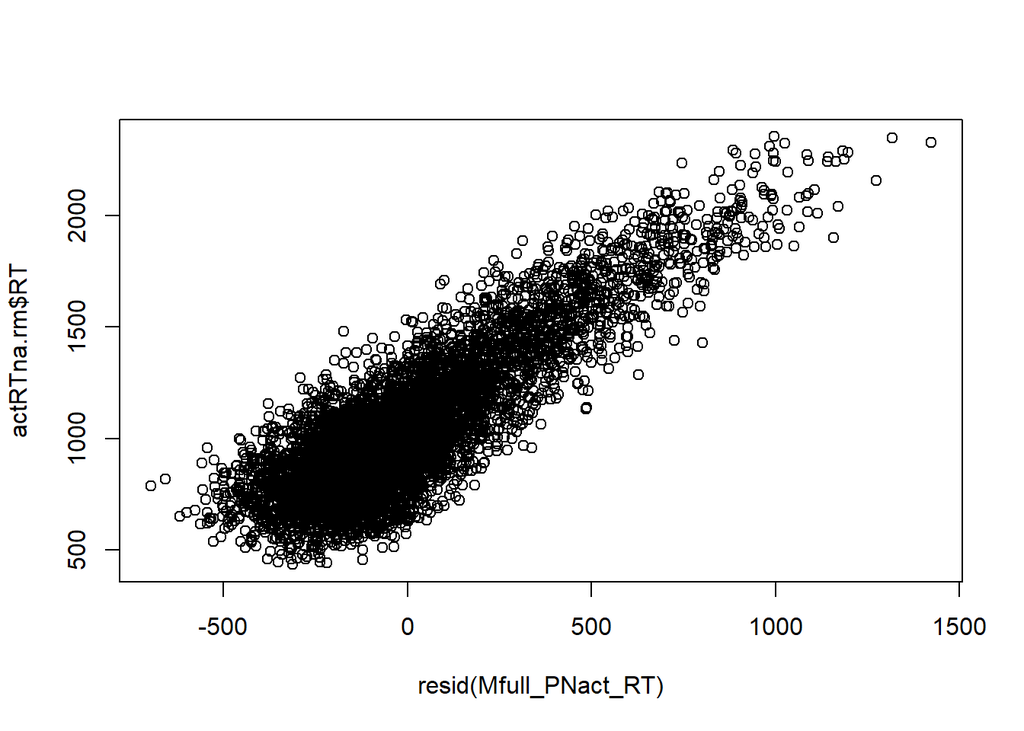

```r
plot(resid(Mfull_PNact_RT), actRTna.rm$RT)
```

We can assume linearity.

##### Assumption 2 - Homogeneity of Variance / Homoscedasticity

```r
#Extracts the residuals and places them in a new column in RTna.rm
actRTna.rm$Mfull.Res <- residuals(Mfull_PNact_RT)
#Takes the absolute values of the residuals
actRTna.rm$Abs.Mfull.Res <- abs(actRTna.rm$Mfull.Res)
#Squares the absolute values to provide the more robust estimate
actRTna.rm$Mfull.Res2 <- actRTna.rm$Abs.Mfull.Res^2

#ANOVA of the squared residuals
Levene.Mfull <- lm(Mfull.Res2 ~ ID, data=actRTna.rm)
anova(Levene.Mfull) #Displays the results
```

```
## Analysis of Variance Table
##
## Response: Mfull.Res2
##             Df     Sum Sq    Mean Sq F value Pr(>F)
## ID           1 3.2805e+10 3.2805e+10   1.464 0.2263
## Residuals 6475 1.4509e+14 2.2408e+10
```

p>0.05,so we can assume homogeneity of variance/homoscedasticity

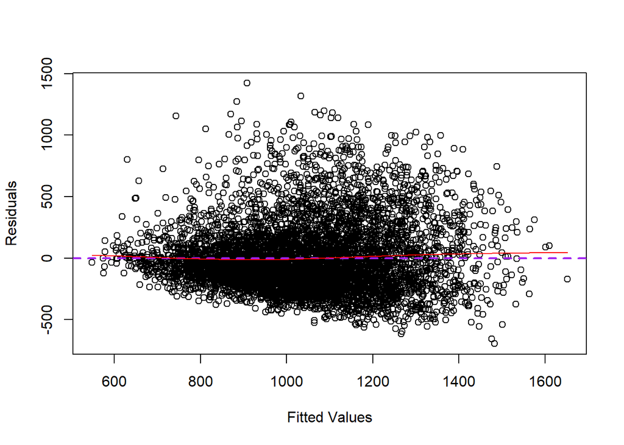

```r
#Create plot for homogeneity of variance
plot(fitted(Mfull_PNact_RT), residuals(Mfull_PNact_RT),
     xlab = "Fitted Values", ylab="Residuals")
abline(h=0, lty=2, lwd=2, col="purple")
lines(smooth.spline(fitted(Mfull_PNact_RT), residuals(Mfull_PNact_RT)), col="red")
```

Purple and red line roughly overlap, so we can assume homoscedasticity

##### Assumption 3 - Residuals are normally distributed

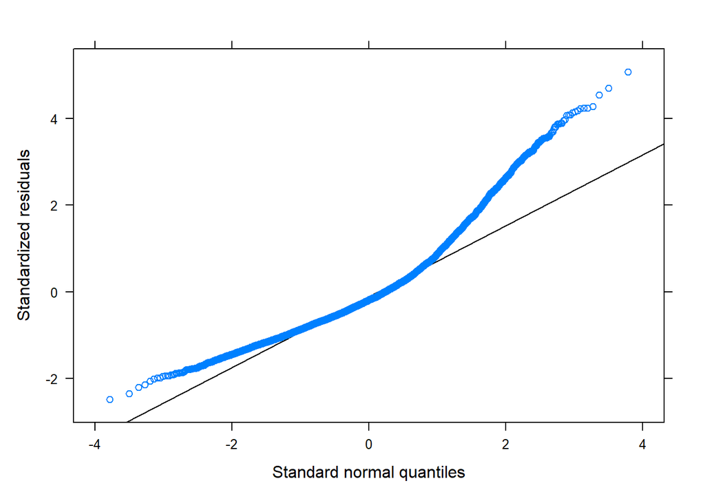

```r
#Create qq plot of the full model
qqmath(Mfull_PNact_RT)
```

Where does the bulk on the right and the outliers on the left come from?

After checking outliers: outliers on the left are now gone and were driven by a typo in the RT transcription of one participant

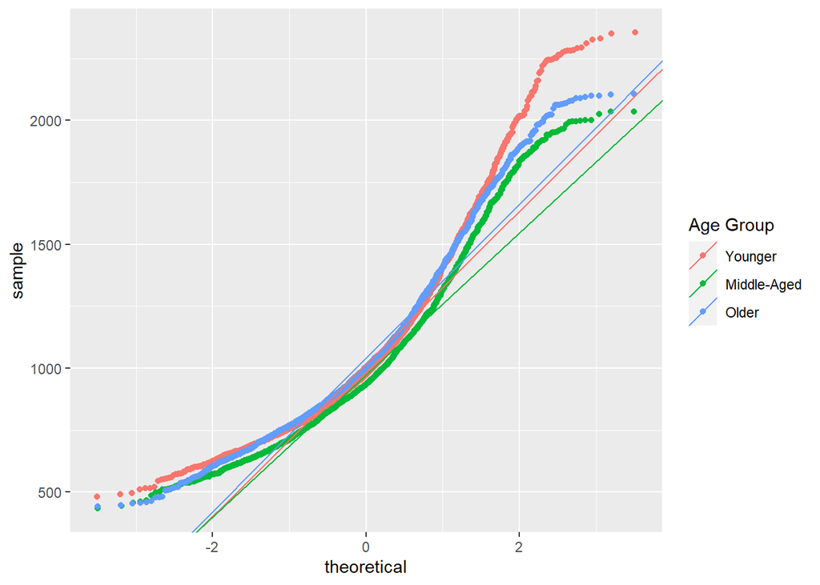

```r
#Check whether the deviations from the QQplot are due to age category
dda <- cbind(augment(Mfull_PNact_RT), group=actRTna.rm$Age.Category)
sample_var <- "RT"
group_var  <- "Age.Category"

# code to compute the slope and the intercept of the qq-line per group

qqlines <- function(vec, group) {
    x <- qnorm(c(0.25, 0.75))
    y <- quantile(vec[!is.na(vec)], c(0.25, 0.75))
    slope <- diff(y)/diff(x)
    int <- y[1] - slope * x[1]
    data.frame(slope, int, group)
}

slopedf <- do.call(rbind,lapply(unique(dda$group), function(grp) qqlines(dda[dda$group == grp,sample_var], grp)))

#Create ggplot of the qq-line per age group to check for differences between age groups
p <- ggplot(dda)+stat_qq(aes_string(sample=sample_var, colour=group_var)) +
    geom_abline(data = slopedf, aes(slope = slope, intercept = int, colour = group)) +
    scale_colour_discrete(guide=guide_legend(title = "Age Group"), labels=c("Younger","Middle-Aged", "Older"))
p
```

The younger age category seems to have a bigger bulk at the right but all age groups follow a similar pattern.

Try log transformation.

```r
#Full model with log-transformed Reaction Times as outcome variable
logMfull_PNact_RT <- lmer(log(RT) ~ Age.Category*CR.composite.before + zSoP.comp + zWM.Score + zStroop.SRC + (1|ID)  + (1|Trial.Number), data=PNactions_RT, REML=FALSE)
```

*Checking the dimensionality of the variance-covariance matrices of random effects assumed in a maximal LMM*

The number of principal components that cumulatively account for 100% of the variance is a reasonably stringent criterion for settling on the reduced dimensionality (Bates et al., 2015)

```r
summary(rePCA(logMfull_PNact_RT))
```

```
## $ID
## Importance of components:
##                          [,1]
## Standard deviation     0.4471
## Proportion of Variance 1.0000
## Cumulative Proportion  1.0000
##
## $Trial.Number
## Importance of components:
##                         [,1]
## Standard deviation     0.497
## Proportion of Variance 1.000
## Cumulative Proportion  1.000
```

To assess overfitting of the model, we conducted a principal components analysis (PCA) of the random effects variance-covariance structure. The PCA did not indicate overspecification of the random effects for ID or Trial. Hence, we report the analysis using the full model with both random effects.

*Checking variance explained by random factors:*

```r
0.01186/(0.01186+0.01466+0.05933) #~13.8% of variance that's left over after the variance explained by our predictor variables is explained by ID (i.e. subject)
```

```
## [1] 0.1381479
```

```r
0.01466/(0.01186+0.01466+0.05933) #~17.1% of variance that's left over after the variance explained by our predictor variables is explained by trial (i.e. stimuli)
```

```
## [1] 0.170763
```

*Recheck model fit after log transformation*

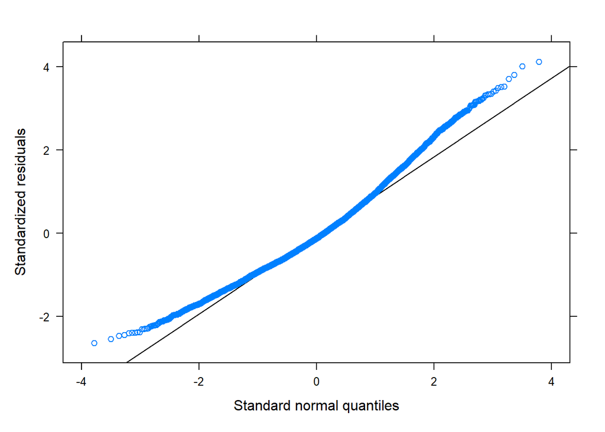

```r
## Normality of residuals
qqmath(logMfull_PNact_RT)
```

Looks much better now. Except the bulk on the left and right. But we will assume the assumption of normality of residuals is met.

*Data per participant:*

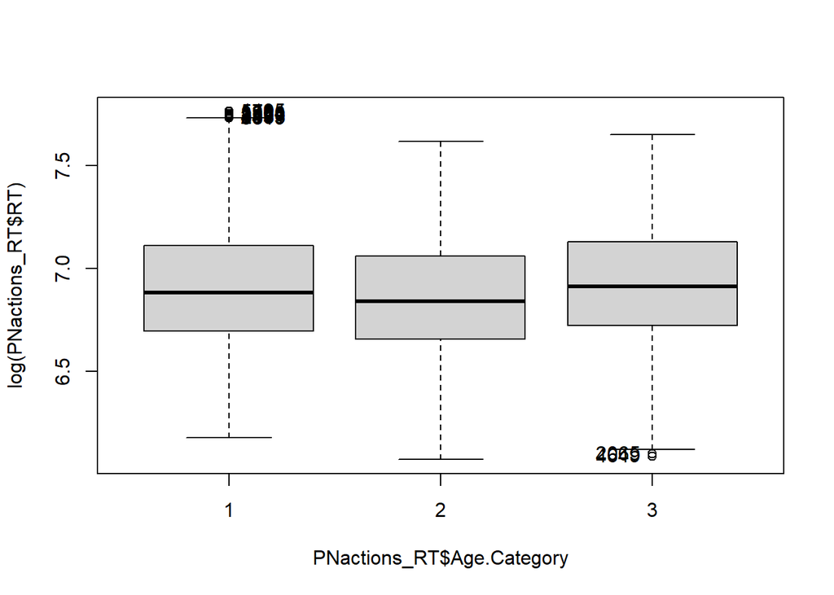

```
##  [1] "579"  "1195" "1264" "2181" "2433" "3129" "3968" "4571" "5819" "5903"
## [11] "2065" "4649"
```

```r
actdataPP <- PNactions_RT %>%
  dplyr::group_by(ID) %>%
  dplyr::summarise(meanRT = mean(RT, na.rm=T),
            sdRT = sd(RT, na.rm=T))

#To look more into depth for any outliers and deviations.
car::Boxplot(log(PNactions_RT$RT) ~ PNactions_RT$Age.Category, id.method="identify")
```

Check each row in the table that was detected as outlier.

–> these outliers don’t seem to strange seen the frequencies of the words/pictures. A possibility would be the effect of online study. Distractions from home (longer RTs), differences in microphone or distance from microphone (causing either smaller or longer RTs than average), maybe they were positively/negatively primed somehow.

*Histogram of transformed RTs for action naming*

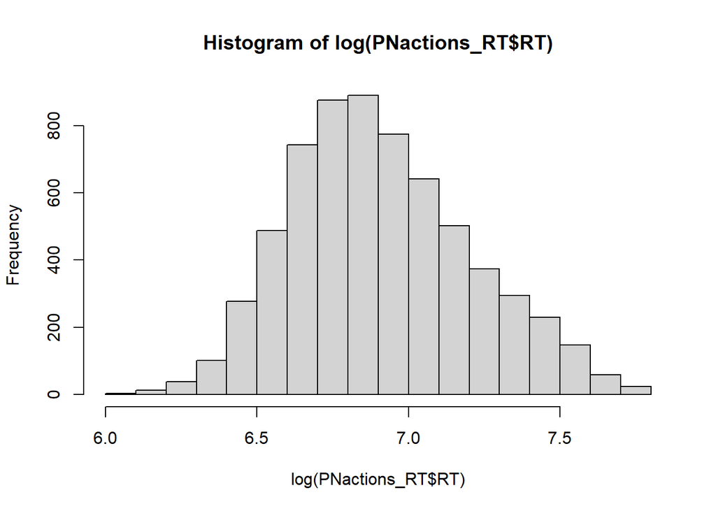

```r
hist(log(PNactions_RT$RT))
```

*Homoscedasticity with log-transformed reaction time*

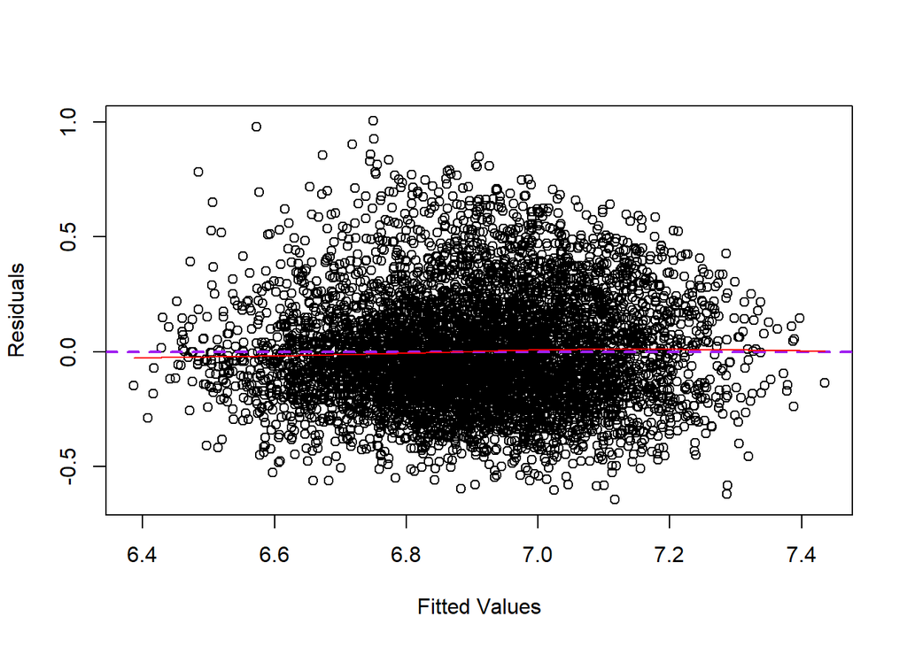

```r
plot(fitted(logMfull_PNact_RT), residuals(logMfull_PNact_RT),
     xlab = "Fitted Values", ylab="Residuals")
abline(h=0, lty=2, lwd=2, col="purple")
lines(smooth.spline(fitted(logMfull_PNact_RT), residuals(logMfull_PNact_RT)), col="red")
```

Purple and red line roughly overlap, so we can assume homoscedasticity

### Results log RT action naming

```r
#Quick overview full model outcome
glance(logMfull_PNact_RT)
```

```
## # A tibble: 1 x 6
##   sigma logLik   AIC   BIC deviance df.residual
##   <dbl>  <dbl> <dbl> <dbl>    <dbl>       <int>
## 1 0.244  -284.  592.  673.     568.        6465
```

```r
#Tidy model summary
(log_tidyMfull_PNactRT <- broom.mixed::tidy(logMfull_PNact_RT, effects = "fixed", conf.int=T, conf.level=0.95))
```

```
## # A tibble: 9 x 9
##   effect term    estimate std.error statistic    df   p.value conf.low conf.high
##   <chr>  <chr>      <dbl>     <dbl>     <dbl> <dbl>     <dbl>    <dbl>     <dbl>
## 1 fixed  (Inter~  6.97       0.0284   245.    135.  1.24e-180  6.91e+0   7.02
## 2 fixed  Age.Ca~ -0.0855     0.0318    -2.68   89.3 8.69e-  3 -1.49e-1  -0.0222
## 3 fixed  Age.Ca~ -0.0601     0.0403    -1.49   89.4 1.39e-  1 -1.40e-1   0.0200
## 4 fixed  CR.com~  0.0231     0.0210     1.10   89.4 2.75e-  1 -1.87e-2   0.0649
## 5 fixed  zSoP.c~  0.0633     0.0225     2.81   89.7 6.04e-  3  1.86e-2   0.108
## 6 fixed  zWM.Sc~  0.0310     0.0153     2.03   87.5 4.58e-  2  5.90e-4   0.0615
## 7 fixed  zStroo~ -0.00344    0.0140    -0.246  89.6 8.07e-  1 -3.13e-2   0.0244
## 8 fixed  Age.Ca~ -0.0259     0.0297    -0.872  89.3 3.86e-  1 -8.51e-2   0.0332
## 9 fixed  Age.Ca~ -0.0623     0.0301    -2.07   89.5 4.11e-  2 -1.22e-1  -0.00257
```

```r
## Write tidy table to .csv file
# write.csv(log_tidyMfull_PNactRT, file = "./Figures and Tables/logPNact_lmerFull.csv", row.names=F)
```

*Effect Size - R squared*

```r
r2_nakagawa(logMfull_PNact_RT)
```

```
## # R2 for Mixed Models
##
##   Conditional R2: 0.338
##      Marginal R2: 0.042
```

Marginal R2 is the variance explained by fixed effects. Theoretical is for binomial distributions. Conditional R2 is the variance explained by the whole model.

## Picture Naming Objects

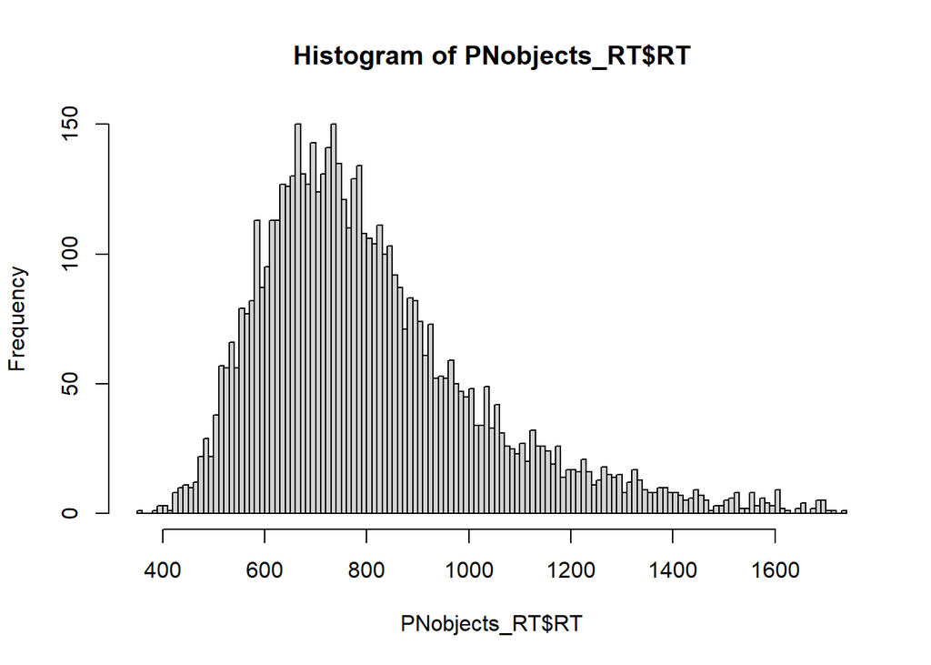

```r
PNobjects_RT <- PN_RT %>%
  # Only include trials for object naming (i.e., type==2)
  dplyr::filter(type==2) %>%
  group_by(ID, Name) %>%
  slice(1) %>%
  ungroup()
  # Check
    # unique(PNobjects_RT$Task.Name) #objects

## Create histogram for distribution
hist(PNobjects_RT$RT, breaks = 100)
```

```r
skewness(log(PNobjects_RT$RT))
```

```
## [1] 0.4341801
```

0.44 -> positively skewed but within limits (Bryne, 2010; George & Mallery, 2010)

### LMER for Objects

*Should we include Trial and ID as random effects?*

```r
#Base model with log-transformed reaction time
Mbase_obj <- lm(log(RT) ~ 1, data=PNobjects_RT)
#Base model with only ID/individual variability as random effect
Mrandom.ID_obj <- lmer(log(RT) ~ 1 +(1|ID), data=PNobjects_RT)
#Base model with only Trial.Number/trial variability as random effect
Mrandom.Trial_obj <- lmer(log(RT) ~ 1 +(1|Trial.Number), data=PNobjects_RT)
#Base model with both random effects
Mrandom.All_obj <- lmer(log(RT) ~ 1 +(1|ID) + (1|Trial.Number), data=PNobjects_RT)
```

AIC base model

```r
#Obtain AIC values for each model
(AIC.base_obj <- AIC(logLik(Mbase_obj)))
```

```
## [1] 683.5062
```

AIC - only ID as random effect

```r
(AIC.reID_obj <- AIC(logLik(Mrandom.ID_obj)))
```

```
## [1] -1156.379
```

AIC - only trial as random effect

```r
(AIC.reTrial_obj <- AIC(logLik(Mrandom.Trial_obj)))
```

```
## [1] 384.5348
```

AIC - both ID and trial as random effect

```r
(AIC.reBoth_obj <- AIC(logLik(Mrandom.All_obj)))
```

```
## [1] -1705.234
```

The AIC for the model including both random effects is lowest –> we justified inclusion of both Trial and Subject as random effects.

*Null model of reaction times for object naming with random effects included*

```r
M0_PNobjRT <- lmer(RT ~ 1 +(1|ID) + (1|Trial.Number), data=PNobjects_RT, REML=FALSE)
summary(M0_PNobjRT)
```

```
## Linear mixed model fit by maximum likelihood . t-tests use Satterthwaite's
##   method [lmerModLmerTest]
## Formula: RT ~ 1 + (1 | ID) + (1 | Trial.Number)
##    Data: PNobjects_RT
##
##      AIC      BIC   logLik deviance df.resid
##  77921.5  77948.2 -38956.7  77913.5     5852
##
## Scaled residuals:
##     Min      1Q  Median      3Q     Max
## -3.2846 -0.6189 -0.1896  0.3709  5.3786
##
## Random effects:
##  Groups       Name        Variance Std.Dev.
##  ID           (Intercept) 13219    114.98
##  Trial.Number (Intercept)  4125     64.22
##  Residual                 32443    180.12
## Number of obs: 5856, groups:  ID, 90; Trial.Number, 70
##
## Fixed effects:
##             Estimate Std. Error     df t value Pr(>|t|)
## (Intercept)   812.40      14.54 139.65   55.86   <2e-16 ***
## ---
## Signif. codes:  0 '***' 0.001 '**' 0.01 '*' 0.05 '.' 0.1 ' ' 1
```

*Unconditional model, i.e., the model without covariates/control measures*

```r
Muncond_PNobjRT <- lmer(RT ~ Age.Category*CR.composite.before + (1|ID)  + (1|Trial.Number), data=PNobjects_RT, REML=FALSE)
```

*Full model, i.e., model with covariates/control measures. RT not log-transformed*

```r
Mfull_PNobj_RT <- lmer(RT ~ Age.Category*CR.composite.before + zSoP.comp + zWM.Score + zStroop.SRC + (1|ID)  + (1|Trial.Number), data=PNobjects_RT, REML=FALSE)
# summary(Mfull_PNobj_RT)

##Create a tidy output table for the fixed effects
(tidyMfull_PNobjRT <- broom.mixed::tidy(Mfull_PNobj_RT, effect = "fixed",conf.int=T, conf.level=0.95))
```

```
## # A tibble: 9 x 9
##   effect term     estimate std.error statistic    df  p.value conf.low conf.high
##   <chr>  <chr>       <dbl>     <dbl>     <dbl> <dbl>    <dbl>    <dbl>     <dbl>
## 1 fixed  (Interc~   788.        22.7    34.7   112.  1.33e-61   743.     833.
## 2 fixed  Age.Cat~     3.97      27.3     0.146  89.7 8.85e- 1   -50.2     58.1
## 3 fixed  Age.Cat~    78.5       34.5     2.27   89.9 2.53e- 2     9.93   147.
## 4 fixed  CR.comp~    22.0       18.0     1.22   90.0 2.25e- 1   -13.8     57.8
## 5 fixed  zSoP.co~    43.2       19.2     2.24   89.8 2.72e- 2     4.97    81.4
## 6 fixed  zWM.Sco~    25.0       13.2     1.90   89.9 6.09e- 2    -1.17    51.2
## 7 fixed  zStroop~   -16.9       12.0    -1.41   89.8 1.61e- 1   -40.8      6.89
## 8 fixed  Age.Cat~   -39.2       25.5    -1.54   89.9 1.27e- 1   -89.9     11.4
## 9 fixed  Age.Cat~   -52.1       25.8    -2.02   90.0 4.59e- 2  -103.      -0.977
```

#### Checking Assumptions LMER Objects

##### Assumption 1 - Linearity

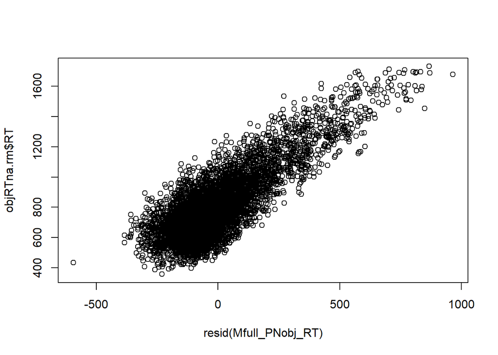

```r
plot(resid(Mfull_PNobj_RT), objRTna.rm$RT)
```

We can assume linearity.

##### Assumption 2 - Homogeneity of Variance / Homoscedasticity

```r
#Extracts the residuals and places them in a new column in RTna.rm
objRTna.rm$Mfull.Res <- residuals(Mfull_PNobj_RT)
#Takes the absolute values of the residuals
objRTna.rm$Abs.Mfull.Res <- abs(objRTna.rm$Mfull.Res)
#Squares the absolute values to provide the more robust estimate
objRTna.rm$Mfull.Res2 <- objRTna.rm$Abs.Mfull.Res^2

#ANOVA of the squared residuals
Levene.Mfull <- lm(Mfull.Res2 ~ ID, data=objRTna.rm)
anova(Levene.Mfull) #Displays the results
```

```
## Analysis of Variance Table
##
## Response: Mfull.Res2
##             Df     Sum Sq    Mean Sq F value Pr(>F)
## ID           1 1.3674e+09 1367398697  0.2761 0.5993
## Residuals 5854 2.8994e+13 4952785342
```

p>0.05,so we can assume homogeneity of variance/homoscedasticity

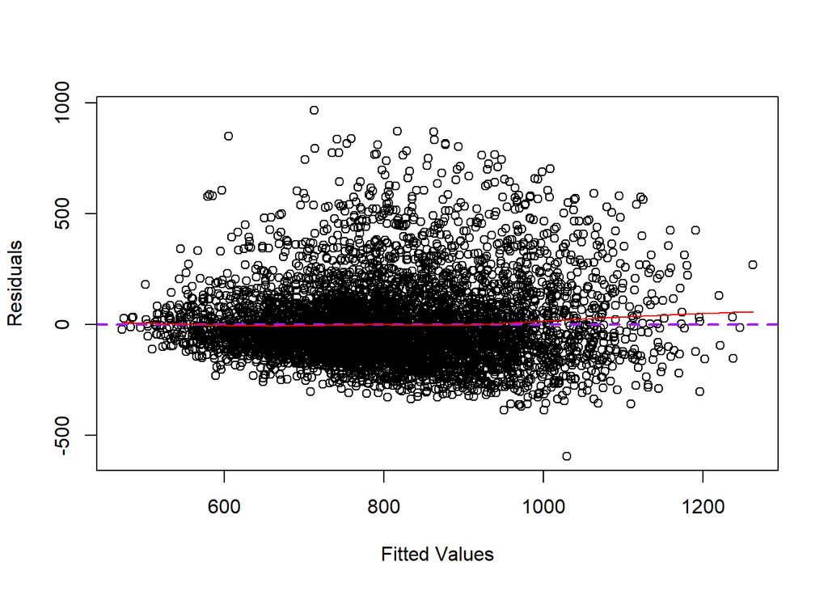

```r
#Create plot for homogeneity of variance
plot(fitted(Mfull_PNobj_RT), residuals(Mfull_PNobj_RT),
     xlab = "Fitted Values", ylab="Residuals")
abline(h=0, lty=2, lwd=2, col="purple")
lines(smooth.spline(fitted(Mfull_PNobj_RT), residuals(Mfull_PNobj_RT)), col="red")
```

Purple and red line roughly overlap, so we can assume homoscedasticity

##### Assumption 3 - Residuals are normally distributed

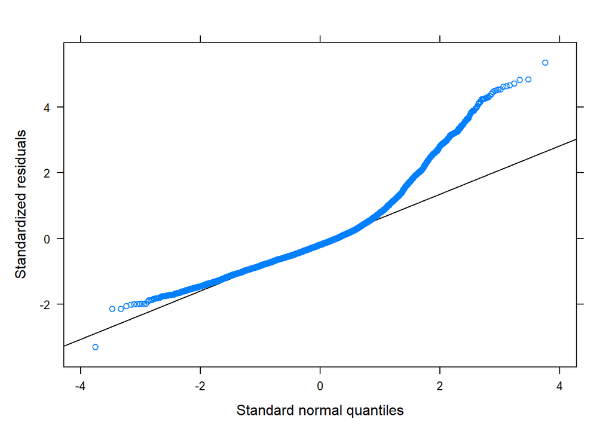

```r
#QQ plot to check normality of residuals
qqmath(Mfull_PNobj_RT)
```

Where does the bulk on the right come from? (CHECK OUTLIERS)

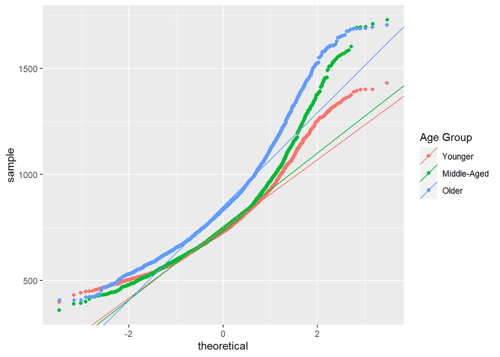

```r
#Check whether the deviations from the QQplot are due to age category
dda <- cbind(augment(Mfull_PNobj_RT), group=objRTna.rm$Age.Category)
sample_var <- "RT"
group_var  <- "Age.Category"

# code to compute the slope and the intercept of the qq-line

qqlines <- function(vec, group) {
    x <- qnorm(c(0.25, 0.75))
    y <- quantile(vec[!is.na(vec)], c(0.25, 0.75))
    slope <- diff(y)/diff(x)
    int <- y[1] - slope * x[1]
    data.frame(slope, int, group)
}

slopedf <- do.call(rbind,lapply(unique(dda$group), function(grp) qqlines(dda[dda$group == grp,sample_var], grp)))

#Create ggplot of the qq-line per age group to check for differences between age groups
p <- ggplot(dda)+stat_qq(aes_string(sample=sample_var, colour=group_var)) +
    geom_abline(data = slopedf, aes(slope = slope, intercept = int, colour = group))+
      scale_colour_discrete(guide=guide_legend(title = "Age Group"), labels=c("Younger","Middle-Aged", "Older"))

p
```

The Older age group seems to have a bigger bulk at the right but all age groups follow a similar pattern.

Try log transformation.

```r
#Full model with log-transformed Reaction Times as outcome variable
logMfull_PNobj_RT <- lmer(log(RT) ~ Age.Category*CR.composite.before + zSoP.comp + zWM.Score + zStroop.SRC + (1|ID)  + (1|Trial.Number), data=PNobjects_RT, REML=FALSE)
```

*Checking the dimensionality of the variance-covariance matrices of random effects assumed in a maximal LMM*

The number of principal components that cumulatively account for 100% of the variance is a reasonably stringent criterion for settling on the reduced dimensionality (Bates et al., 2015)

```r
summary(rePCA(logMfull_PNobj_RT))
```

```
## $ID
## Importance of components:
##                          [,1]
## Standard deviation     0.5959
## Proportion of Variance 1.0000
## Cumulative Proportion  1.0000
##
## $Trial.Number
## Importance of components:
##                          [,1]
## Standard deviation     0.3725
## Proportion of Variance 1.0000
## Cumulative Proportion  1.0000
```

To assess overfitting of the model, we conducted a principal components analysis (PCA) of the random effects variance-covariance structure. The PCA did not indicate overspecification of the random effects for ID or Trial. Hence, we report the analysis using the full model with both random effects.

*Checking variance explained by random factors:*

```r
0.014247 /(0.014247 + 0.005567  +0.040128  ) #~23.8% of variance that's left over after the variance explained by our predictor variables is explained by ID (i.e. subject)
```

```
## [1] 0.2376798
```

```r
 0.005567  /(0.014247 + 0.005567  +0.040128  ) #~9.3% of variance that's left over after the variance explained by our predictor variables is explained by trial (i.e. stimuli)
```

```
## [1] 0.09287311
```

*Recheck model fit after log transformation*

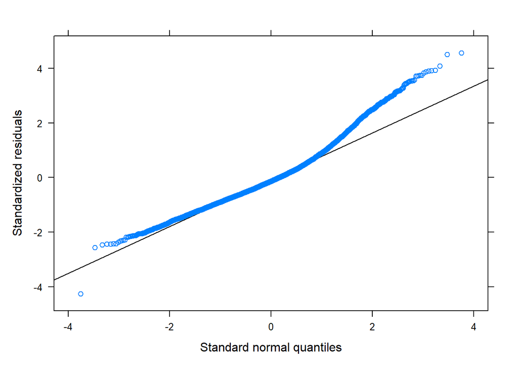

```r
## Normality of residuals
qqmath(logMfull_PNobj_RT)
```

Looks much better now. Except the outliers on the right. We will assume normality of residuals.

*Data per participant:*

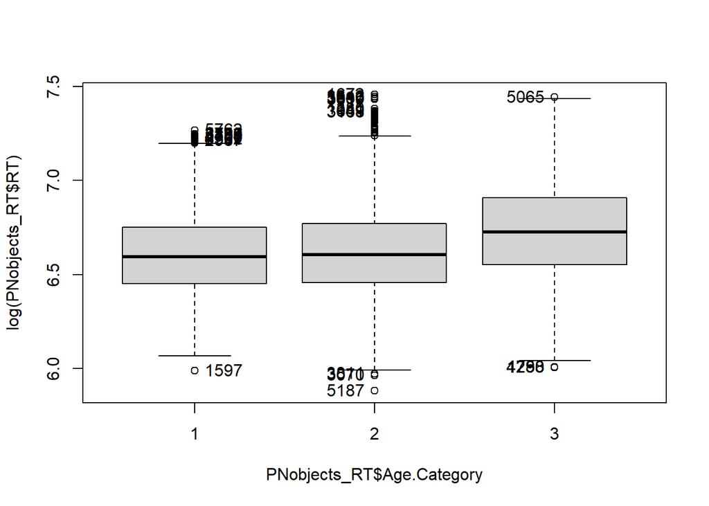

```
##  [1] "1597" "5762" "5719" "3356" "2105" "5437" "4334" "4700" "4362" "3311"
## [11] "2987" "3070" "3811" "5187" "1672" "3640" "5385" "3530" "1097" "3619"
## [21] "1380" "941"  "3639" "3168" "1750" "4288" "4293" "5065"
```

```r
objdataPP <- PNobjects_RT %>%
  dplyr::group_by(ID) %>%
  dplyr::summarise(meanRT = mean(RT, na.rm=T),
            sdRT = sd(RT, na.rm=T))

#To look more into depth for any outliers and deviations.
car::Boxplot(log(PNobjects_RT$RT) ~ PNobjects_RT$Age.Category, id.method="identify")
```

Check each row in the table that was detected as outlier.

*Histogram of transformed RTs for object naming*

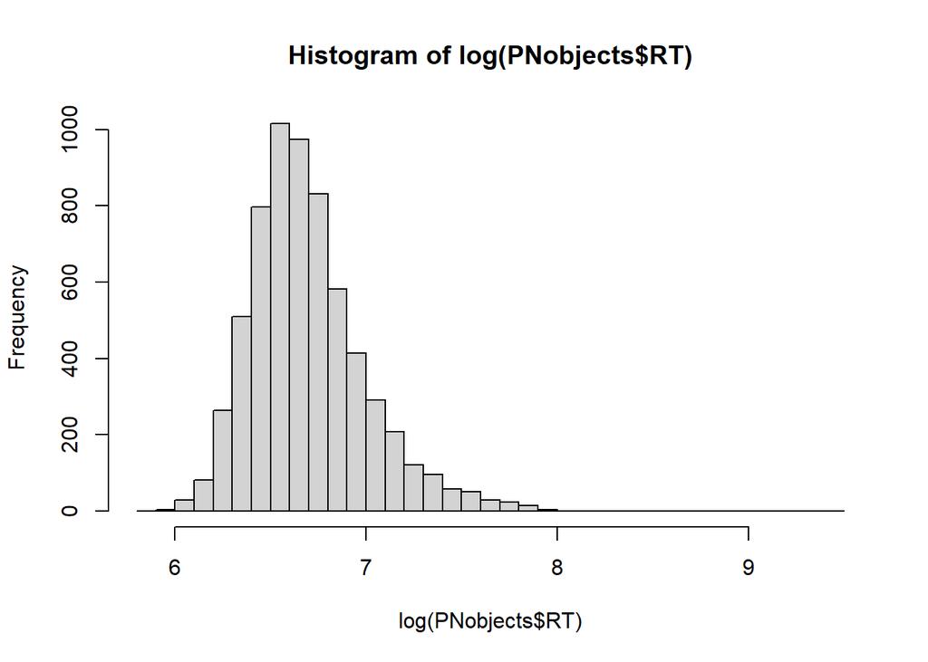

```r
hist(log(PNobjects$RT),breaks=50)
```

*Homoscedasticity with log-transformed reaction time*

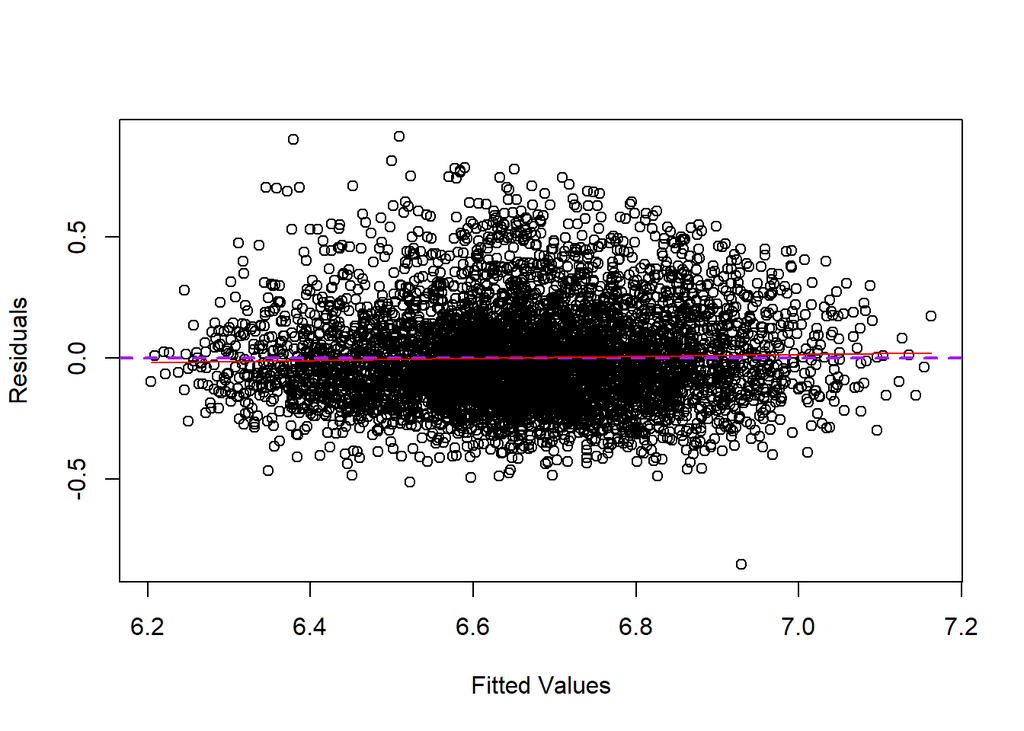

```r
plot(fitted(logMfull_PNobj_RT), residuals(logMfull_PNobj_RT),
     xlab = "Fitted Values", ylab="Residuals")
abline(h=0, lty=2, lwd=2, col="purple")
lines(smooth.spline(fitted(logMfull_PNobj_RT), residuals(logMfull_PNobj_RT)), col="red")
```

Purple and red line roughly overlap, so we can assume homoscedasticity

### Results RT object naming

```r
#Quick overview full model outcome
glance(logMfull_PNobj_RT)
```

```
## # A tibble: 1 x 6
##   sigma logLik    AIC    BIC deviance df.residual
##   <dbl>  <dbl>  <dbl>  <dbl>    <dbl>       <int>
## 1 0.200   876. -1728. -1647.   -1752.        5844
```

```r
#Tidy model summary
(log_tidyMfull_PNobjRT <- broom.mixed::tidy(logMfull_PNobj_RT, effects = "fixed", conf.int=T, conf.level=0.95))
```

```
## # A tibble: 9 x 9
##   effect term    estimate std.error statistic    df   p.value conf.low conf.high
##   <chr>  <chr>      <dbl>     <dbl>     <dbl> <dbl>     <dbl>    <dbl>     <dbl>
## 1 fixed  (Inter~  6.65       0.0284   234.    109.  1.62e-148  6.59e+0   6.70
## 2 fixed  Age.Ca~ -0.00512    0.0345    -0.149  89.8 8.82e-  1 -7.36e-2   0.0634
## 3 fixed  Age.Ca~  0.0765     0.0436     1.75   89.9 8.28e-  2 -1.01e-2   0.163
## 4 fixed  CR.com~  0.0253     0.0228     1.11   90.0 2.70e-  1 -2.00e-2   0.0705
## 5 fixed  zSoP.c~  0.0596     0.0243     2.45   89.9 1.61e-  2  1.13e-2   0.108
## 6 fixed  zWM.Sc~  0.0338     0.0167     2.03   90.0 4.57e-  2  6.67e-4   0.0669
## 7 fixed  zStroo~ -0.0205     0.0152    -1.35   89.9 1.80e-  1 -5.06e-2   0.00962
## 8 fixed  Age.Ca~ -0.0374     0.0322    -1.16   89.9 2.48e-  1 -1.01e-1   0.0265
## 9 fixed  Age.Ca~ -0.0636     0.0325    -1.96   90.0 5.36e-  2 -1.28e-1   0.00101
```

```r
## Write tidy table to .csv file
# write.csv(log_tidyMfull_PNobjRT, file = "./Figures and Tables/logPNobj_lmerFull.csv", row.names=F)
```

*Effect Size - R squared*

```r
r2_nakagawa(logMfull_PNobj_RT)
```

```
## # R2 for Mixed Models
##
##   Conditional R2: 0.395
##      Marginal R2: 0.096
```

Marginal R2 is the variance explained by fixed effects. Theoretical is for binomial distributions. Conditional R2 is the variance explained by the whole model.

## Visualising significant predictors

```r
#Create labels for legend per age group
Ages = as_labeller(c(`1`="Younger", `2`="Middle-Aged", `3`="Older"))

#Colour Palette - colourblind friendly
cbbPalette <- c("#999999", "#E69F00", "#56B4E9")
```

*Relationship RT and Cognitive Processing speed for reaction time (outcome) of picture naming Actions*

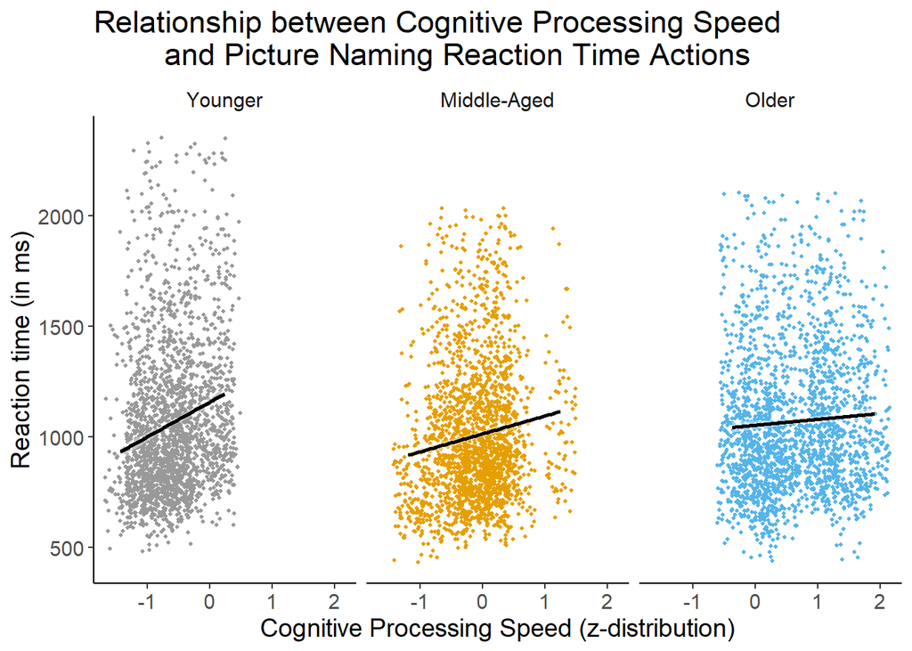

```r
(plot.PNact_zSOP <- ggplot(PNactions_RT, aes(x=zSoP.comp, y=RT, colour=as.factor(Age.Category))) +
   geom_jitter(width = 0.25, size=0.8, show.legend =F) +
   geom_smooth(method = "lm", formula = y~x, fill="white", colour="black", show.legend=F) +
   labs(x = "Cognitive Processing Speed (z-distribution)",
        y= "Reaction time (in ms)",
        title = "Relationship between Cognitive Processing Speed
        and Picture Naming Reaction Time Actions") +
   facet_grid(~Age.Category, labeller=labeller(Age.Category=Ages)) +
    theme(text = element_text(size = 14),
          panel.background  = element_rect(fill="white"),
          plot.background = element_rect(fill = "white"),
          strip.background = element_rect(fill="white"),
          axis.line.x = element_line(color="black"),
         axis.line.y = element_line(color="black")) +
         scale_colour_manual(values = cbbPalette))
```

*Relationship RT and Cognitive Processing Speed for reaction time (outcome) of picture naming Objects*

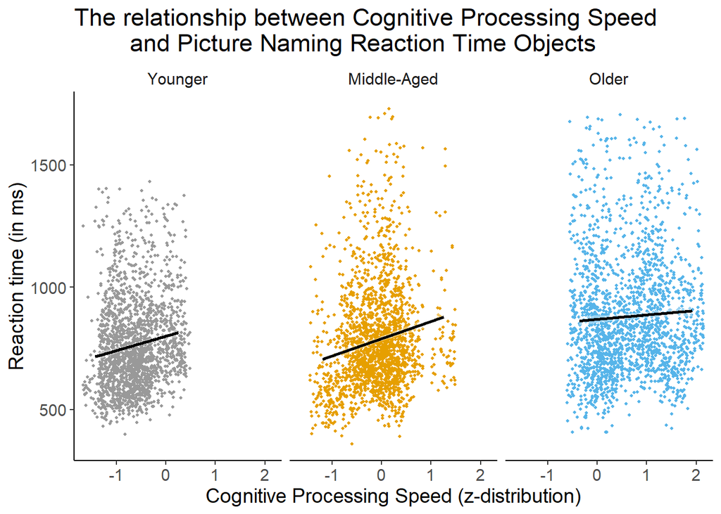

```r
(plot.PNobj_zSOP <- ggplot(PNobjects_RT, aes(x=zSoP.comp, y=RT, colour=as.factor(Age.Category))) +
   geom_jitter(size=0.8, width = 0.25, show.legend=F) +
   geom_smooth(method = "lm", formula = y~x, fill="white", size=1, colour="black") +
   labs(x = "Cognitive Processing Speed (z-distribution)",
        y= "Reaction time (in ms)",
        title = "The relationship between Cognitive Processing Speed
        and Picture Naming Reaction Time Objects")+
   facet_grid(~Age.Category, labeller=labeller(Age.Category=Ages)) +
   theme(text = element_text(size = 14),
          panel.background  = element_rect(fill="white"),
          plot.background = element_rect(fill = "white"),
          strip.background = element_rect(fill="white"),
          axis.line.x = element_line(color="black"),
         axis.line.y = element_line(color="black")) +
         scale_colour_manual(values = cbbPalette))
```

*Relationship Reaction Times and Cognitive Reserve (CR) for the period preceding the COVID-19 pandemic for reaction time (outcome) of picture naming Actions*

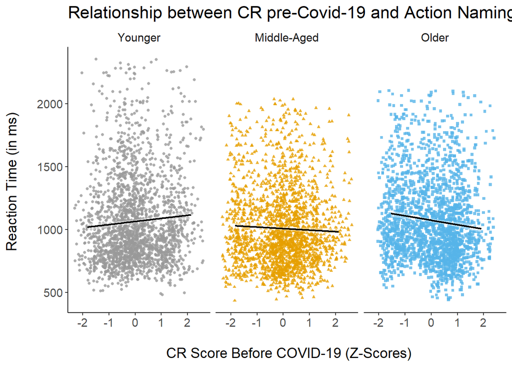

```r
#Save figure as tiff file
# tiff(file="./Figures and Tables/Figure_1.tiff",
# res = 300, family = "sans", width = 7, height=4.5, units="in")

(plot.PNact_CR <- ggplot(PNactions_RT, aes(x=CR.composite.before, y=RT, shape=as.factor(Age.Category),colour = as.factor(Age.Category))) +
   geom_jitter(width = 0.5, height=0.25, size=1, show.legend = F, alpha=.8) +
   geom_smooth(method = "lm", formula = y~x, fill="white", colour="black", show.legend = F, size=.8) +
   labs(x = "\n CR Score Before COVID-19 (Z-Scores)",
        y= "Reaction Time (in ms) \n",
        title = "Relationship between CR pre-Covid-19 and Action Naming RT") +
      facet_grid(.~Age.Category, labeller=labeller(Age.Category=Ages)) +
    theme(text = element_text(size = 14),
          panel.background  = element_rect(fill="white"),
          plot.background = element_rect(fill = "white"),
          strip.background = element_rect(fill="white"),
          axis.line.x = element_line(color="black"),
        axis.line.y = element_line(color="black")) +
  scale_colour_manual(values = cbbPalette))
```

```r
# dev.off()
```

*Relationship Reaction Times and Cognitive reserve for the period preceding the COVID-19 pandemic for reaction time (outcome) of picture naming Objects*

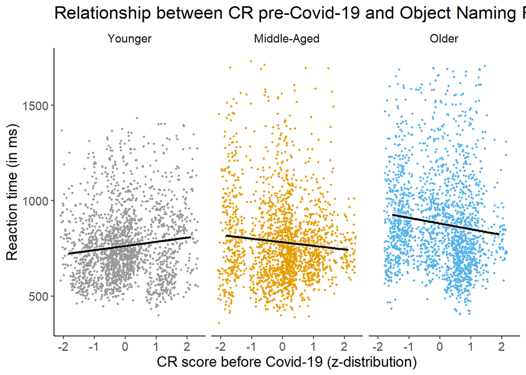

```r
# png(file="./Figures and Tables/RelationCR-PNobjRT.png",
# width=600, height=350)

(plot.PNobj_CR <- ggplot(PNobjects_RT, aes(x=CR.composite.before, y=RT, colour=as.factor(Age.Category))) +
   geom_jitter(width = 0.25, size=0.8, show.legend = F) +
   geom_smooth(method = "lm", formula = y~x, fill="white", colour="black", show.legend = F) +
   labs(x = "CR score before Covid-19 (z-distribution)",
        y= "Reaction time (in ms)",
        title = "Relationship between CR pre-Covid-19 and Object Naming RT") +
   facet_grid(~Age.Category, labeller=labeller(Age.Category=Ages))+
       theme(text = element_text(size = 14),
          panel.background  = element_rect(fill="white"),
          plot.background = element_rect(fill = "white"),
          strip.background = element_rect(fill="white"),
          axis.line.x = element_line(color="black"),
        axis.line.y = element_line(color="black")) +
  scale_colour_manual(values = cbbPalette))
```

```r
# dev.off()
```

### Model comparisons for the CR measure preciding and coinciding with the COVID-19 pandemic

The effect of the COVID-19 pandemic on CR and subsequent behavioural performance

*Action Naming*

```r
#Full Action Naming log model with CR coinciding the COVID-19 pandemic
logMfull_PNact_RT.during <- lmer(log(RT) ~ Age.Category*CR.composite.during + zSoP.comp + zWM.Score + zStroop.SRC + (1|ID)  + (1|Trial.Number), data=PNactions_RT, REML=FALSE)
# summary(logMfull_PNact_RT.during)
```

*Comparing the Action Naming models: preceding vs. coinciding the COVID-19 pandemic*

```r
anova(logMfull_PNact_RT, logMfull_PNact_RT.during)
```

```
## Data: PNactions_RT
## Models:
## logMfull_PNact_RT: log(RT) ~ Age.Category * CR.composite.before + zSoP.comp + zWM.Score +
## logMfull_PNact_RT:     zStroop.SRC + (1 | ID) + (1 | Trial.Number)
## logMfull_PNact_RT.during: log(RT) ~ Age.Category * CR.composite.during + zSoP.comp + zWM.Score +
## logMfull_PNact_RT.during:     zStroop.SRC + (1 | ID) + (1 | Trial.Number)
##                          npar    AIC    BIC  logLik deviance Chisq Df
## logMfull_PNact_RT          12 591.74 673.05 -283.87   567.74
## logMfull_PNact_RT.during   12 592.30 673.61 -284.15   568.30     0  0
##                          Pr(>Chisq)
## logMfull_PNact_RT
## logMfull_PNact_RT.during
```

There are barely any differences between the two models. The AIC is a tiny bit lower for the CR composite score before the pandemic, meaning that that model fits the data slightly better.

*Object Naming*

```r
#Full Object Naming log model with CR coinciding the COVID-19 pandemic
logMfull_PNobj_RT.during <- lmer(log(RT) ~ Age.Category*CR.composite.during + zSoP.comp + zWM.Score + zStroop.SRC + (1|ID)  + (1|Trial.Number), data=PNobjects_RT, REML=FALSE)
# summary(logMfull_PNobj_RT.during)
```

*Comparing the Object Naming models: preceding vs. coinciding the COVID-19 pandemic*

```r
anova(logMfull_PNobj_RT, logMfull_PNobj_RT.during)
```

```
## Data: PNobjects_RT
## Models:
## logMfull_PNobj_RT: log(RT) ~ Age.Category * CR.composite.before + zSoP.comp + zWM.Score +
## logMfull_PNobj_RT:     zStroop.SRC + (1 | ID) + (1 | Trial.Number)
## logMfull_PNobj_RT.during: log(RT) ~ Age.Category * CR.composite.during + zSoP.comp + zWM.Score +
## logMfull_PNobj_RT.during:     zStroop.SRC + (1 | ID) + (1 | Trial.Number)
##                          npar     AIC     BIC logLik deviance  Chisq Df
## logMfull_PNobj_RT          12 -1727.5 -1647.4 875.76  -1751.5
## logMfull_PNobj_RT.during   12 -1728.6 -1648.5 876.32  -1752.6 1.1118  0
##                          Pr(>Chisq)
## logMfull_PNobj_RT
## logMfull_PNobj_RT.during
```

*Descriptives Average CR before and during Covid-19*

```r
CompareCR <- PN_all %>% #dataset with both object and action naming data
  group_by(Age.Category) %>%
  #Create means for CR scores preceding and coinciding with the COVID-19 pandemic
  summarise(CR.before = mean(CR.composite.before),
            CR.during = mean(CR.composite.during)) %>%
  #Convert from wide to long format
  pivot_longer(cols = CR.before:CR.during, names_to = "Period",values_to = "CRscore") %>%
  #Recode age groups as categorical values
    dplyr::mutate(across(Age.Category, ~case_when(
                                    . == 1 ~"Younger",
                                    . == 2 ~"Middle-Aged",
                                    . == 3 ~"Older")))

#Summary table with mean CR scores
CompareCR
```

```
## # A tibble: 6 x 3
##   Age.Category Period     CRscore
##   <chr>        <chr>        <dbl>
## 1 Younger      CR.before  0.0430
## 2 Younger      CR.during -0.0174
## 3 Middle-Aged  CR.before -0.0550
## 4 Middle-Aged  CR.during -0.0566
## 5 Older        CR.before  0.0346
## 6 Older        CR.during -0.00614
```

*Visualisation Average CR before and during Covid-19*

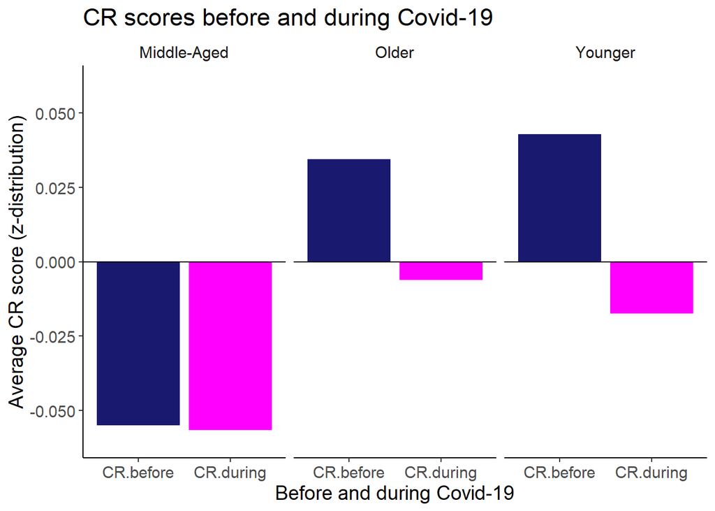

```r
#Save as png file
# png(file="./Figures and Tables/CR_Before-vs-During.png",
# width=350, height=200)

(Barplot_CompareCR <-ggplot(CompareCR, aes(x=as.factor(Period), y=CRscore, fill=as.factor(Period))) +
  stat_summary(geom="bar", fun=mean, position="dodge", show.legend = F) +
  scale_fill_manual(values = c("midnightblue", "magenta"), guide=guide_legend(title = "Period"), labels=c("Before Covid-19","During Covid-19"))+
  coord_cartesian(ylim = c(-.06,.06)) +
  scale_y_continuous(breaks = seq(-.05,.05, 0.025)) +
  labs(title = "CR scores before and during Covid-19",
       x="Before and during Covid-19",
       y="Average CR score (z-distribution)") +
  theme_grey() +
    facet_grid(~Age.Category)+
           theme(text = element_text(size = 14),
          panel.background  = element_rect(fill="white"),
          plot.background = element_rect(fill = "white"),
          strip.background = element_rect(fill="white"),
          axis.line.x = element_line(color="black"),
        axis.line.y = element_line(color="black"))+
   geom_hline(yintercept=0))
```

```r
# dev.off()
```

## References

Bates, Douglas, and Martin Maechler. 2019. *Matrix: Sparse and Dense Matrix Classes and Methods*. http://Matrix.R-forge.R-project.org/.

Bates, Douglas, Martin Maechler, Ben Bolker, and Steven Walker. 2020. *Lme4: Linear Mixed-Effects Models Using Eigen and S4*. https://github.com/lme4/lme4/.

Bates, Douglas, Martin Mächler, Ben Bolker, and Steve Walker. 2015. “Fitting Linear Mixed-Effects Models Using lme4.” *Journal of Statistical Software* 67 (1): 1–48. https://doi.org/10.18637/jss.v067.i01.

Byrne, Barbara M. 2001. *Structural Equation Modeling with AMOS: Basic Concepts, Applications, and Programming*. Multivariate Applications Series. Taylor; Francis.

Chan, Chung-hong, and Thomas J. Leeper. 2021. *Rio: A Swiss-Army Knife for Data i/o*. https://github.com/leeper/rio.

Fox, John, and Sanford Weisberg. 2019. *An R Companion to Applied Regression*. Third. Thousand Oaks CA: Sage. https://socialsciences.mcmaster.ca/jfox/Books/Companion/.

Fox, John, Sanford Weisberg, and Brad Price. 2020. *carData: Companion to Applied Regression Data Sets*. https://CRAN.R-project.org/package=carData.

———. 2021. *Car: Companion to Applied Regression*. https://CRAN.R-project.org/package=car.

George, Darren, and Paul Mallery. 2010. *SPSS for Windows Step by Step: A Simple Guide and Reference 18.0 Update*. 11th ed. USA: Prentice Hall Press.

Henry, Lionel, and Hadley Wickham. 2020. *Purrr: Functional Programming Tools*. https://CRAN.R-project.org/package=purrr.

Hester, Jim, and Hadley Wickham. 2020. *Fs: Cross-Platform File System Operations Based on Libuv*. https://CRAN.R-project.org/package=fs.

Kuznetsova, Alexandra, Per B. Brockhoff, and Rune H. B. Christensen. 2017. “lmerTest Package: Tests in Linear Mixed Effects Models.” *Journal of Statistical Software* 82 (13): 1–26. https://doi.org/10.18637/jss.v082.i13.

Kuznetsova, Alexandra, Per Bruun Brockhoff, and Rune Haubo Bojesen Christensen. 2020. *lmerTest: Tests in Linear Mixed Effects Models*. https://github.com/runehaubo/lmerTestR.

Lüdecke, Daniel. 2021. *sjPlot: Data Visualization for Statistics in Social Science*. https://strengejacke.github.io/sjPlot/.

Lüdecke, Daniel, Mattan S. Ben-Shachar, Indrajeet Patil, Philip Waggoner, and Dominique Makowski. 2021. “performance: An R Package for Assessment, Comparison and Testing of Statistical Models.” *Journal of Open Source Software* 6 (60): 3139. https://doi.org/10.21105/joss.03139.

Lüdecke, Daniel, Dominique Makowski, Mattan S. Ben-Shachar, Indrajeet Patil, Philip Waggoner, and Brenton M. Wiernik. 2021. *Performance: Assessment of Regression Models Performance*. https://easystats.github.io/performance/.

Meyer, David, Evgenia Dimitriadou, Kurt Hornik, Andreas Weingessel, and Friedrich Leisch. 2021. *E1071: Misc Functions of the Department of Statistics, Probability Theory Group (Formerly: E1071), TU Wien*. https://CRAN.R-project.org/package=e1071.

Müller, Kirill, and Hadley Wickham. 2021. *Tibble: Simple Data Frames*. https://CRAN.R-project.org/package=tibble.

R Core Team. 2020. *R: A Language and Environment for Statistical Computing*. Vienna, Austria: R Foundation for Statistical Computing. https://www.R-project.org/.

Robinson, David, Alex Hayes, and Simon Couch. 2021. *Broom: Convert Statistical Objects into Tidy Tibbles*. https://CRAN.R-project.org/package=broom.

Sarkar, Deepayan. 2008. *Lattice: Multivariate Data Visualization with r*. New York: Springer. http://lmdvr.r-forge.r-project.org.

———. 2021. *Lattice: Trellis Graphics for r*. http://lattice.r-forge.r-project.org/.

Sjoberg, David. 2020. *Hablar: Non-Astonishing Results in r*. https://davidsjoberg.github.io/.

Wickham, Hadley. 2016. *Ggplot2: Elegant Graphics for Data Analysis*. Springer-Verlag New York. https://ggplot2.tidyverse.org.

———. 2019. *Stringr: Simple, Consistent Wrappers for Common String Operations*. https://CRAN.R-project.org/package=stringr.

———. 2021a. *Forcats: Tools for Working with Categorical Variables (Factors)*. https://CRAN.R-project.org/package=forcats.

———. 2021b. *Tidyr: Tidy Messy Data*. https://CRAN.R-project.org/package=tidyr.

———. 2021c. *Tidyverse: Easily Install and Load the Tidyverse*. https://CRAN.R-project.org/package=tidyverse.

Wickham, Hadley, Mara Averick, Jennifer Bryan, Winston Chang, Lucy D’Agostino McGowan, Romain François, Garrett Grolemund, et al. 2019. “Welcome to the tidyverse.” *Journal of Open Source Software* 4 (43): 1686. https://doi.org/10.21105/joss.01686.

Wickham, Hadley, and Jennifer Bryan. 2019. *Readxl: Read Excel Files*. https://CRAN.R-project.org/package=readxl.

Wickham, Hadley, Winston Chang, Lionel Henry, Thomas Lin Pedersen, Kohske Takahashi, Claus Wilke, Kara Woo, Hiroaki Yutani, and Dewey Dunnington. 2021. *Ggplot2: Create Elegant Data Visualisations Using the Grammar of Graphics*. https://CRAN.R-project.org/package=ggplot2.

Wickham, Hadley, Romain François, Lionel Henry, and Kirill Müller. 2021. *Dplyr: A Grammar of Data Manipulation*. https://CRAN.R-project.org/package=dplyr.

Wickham, Hadley, and Jim Hester. 2021. *Readr: Read Rectangular Text Data*. https://CRAN.R-project.org/package=readr.

Xie, Yihui. 2014. “Knitr: A Comprehensive Tool for Reproducible Research in R.” In *Implementing Reproducible Computational Research*, edited by Victoria Stodden, Friedrich Leisch, and Roger D. Peng. Chapman; Hall/CRC. http://www.crcpress.com/product/isbn/9781466561595.

———. 2015. *Dynamic Documents with R and Knitr*. 2nd ed. Boca Raton, Florida: Chapman; Hall/CRC. https://yihui.org/knitr/.

———. 2021. *Knitr: A General-Purpose Package for Dynamic Report Generation in r*. https://yihui.org/knitr/.